# Reshape Metadata

## Settup

### Libraries

```r
tellme <- function(name){message("Package ", name, " version: ", packageVersion(name))}

library(tidyr); tellme("tidyr")
suppressPackageStartupMessages(library(dplyr)); tellme("dplyr")
```

```r
library(ggplot2); tellme("ggplot2")
library(ggrepel); tellme("ggrepel")
```

Direct output.

Output will be saved to: `../output`

### read data

Read data.

```r
meta = read.delim("../../input/meta/ANIGMA-metadata.txt") %>%
  select(PARTICIPANT.ID, LOCATION, TIMEPOINT, AGE, SUBTYPE, BMI,
         STAI_Y1, STAI_Y2, STAI_TOTAL, PSS, DAYS_TREAT, Weight_kg)
dim(meta)
```

```
## [1] 352  12
```

Get the per-particpant metadata.

```r
pipeline = "../../"
prevModule = dir(path=pipeline, pattern="Participant_Metadata", full.names = TRUE)
fileName = file.path(prevModule, "output", "ANIGMA-metadata_by_AN_participant.txt")
diffs = read.delim(fileName)
```

Read in data from file: `../..//01_Participant_Metadata/output/ANIGMA-metadata_by_AN_participant.txt`

This table has `118` rows and `25` columns.

### Colors

A named vector of color vectors. Most of these match the previous paper.

### Remove/modify individual data.

Note: 469017 and 469019 are the outliers (same as before!) who lost weight during their stay, this was attributed to medication they had been taking ahead of their stay that lead to inflated weight values on arrival. So the T1 weight (and by extension bmi) is not a valid measure here.

```r
meta[meta$PARTICIPANT.ID=="469017", "BMI"] = NA
meta[meta$PARTICIPANT.ID=="469019", "BMI"] = NA
```

```r
meta[meta$PARTICIPANT.ID=="469021" & meta$TIMEPOINT=="T2", "PSS"] = NA
meta[meta$PARTICIPANT.ID=="469101" & meta$TIMEPOINT=="T1", "PSS"] = NA
```

## MAIN

### BMI

Body mass index (BMI) is a central metic of outcome for these patients. A normal range is 18.5 to 25.

```r
bmi.cat.breaks = c(18.5, 25)
assign.pss.category <- function(x){
  result = rep(NA, length(x))
  result[x < 18.5] = 1
  result[x >= 18.5 & x < 25] = 2
  result[x >= 25 ] = 3
  return(result)
}
```

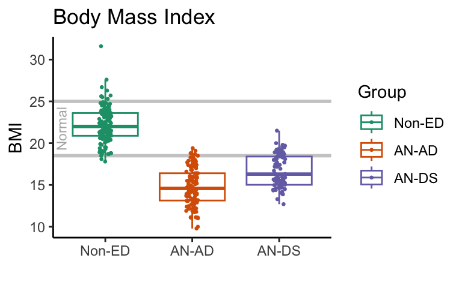

```r
figureLabels = c("Non-ED","AN-AD","AN-DS")

ggplot(data=meta,
                  aes(x=TIMEPOINT, y=BMI, col=TIMEPOINT)) +
    scale_colour_manual(values = myColorPalette,
                        labels=figureLabels, name="Group") +
    geom_hline(yintercept=bmi.cat.breaks, color="gray80", size=1) +
    geom_boxplot(outlier.alpha = 0) +
    geom_jitter(width = .07, height = 0, size=.5) +
    xlab("") +
    annotate("text", y=mean(c(18.5, 25)), x=.5, label="Normal",
             color="gray70", angle=90, size=3) +
    scale_x_discrete(labels=figureLabels) +
    ggtitle("Body Mass Index") +
    theme_classic()
```

```r
bmi.plot.file = file.path(outdir, "bmi-boxplot.png")
ggsave(filename = bmi.plot.file, height = 2.5, width = 4)
```

Saved: `../output/bmi-boxplot.png`

### PSS

Perceived Stress Scale (PSS) is a survey-based metric of patient stress.

Low is 0-13. Moderate is 14-26. High is 27-40.

```r
pss.cat.breaks = c(0, 13.5, 26.5, 40)
assign.pss.category <- function(x){
  result = rep(NA, length(x))
  result[x < 14] = 1
  result[x >= 14 & x < 27] = 2
  result[x >=27 ] = 3
  return(result)
}
```

boxplots

Previously, Kylie showed this data with boxplots.

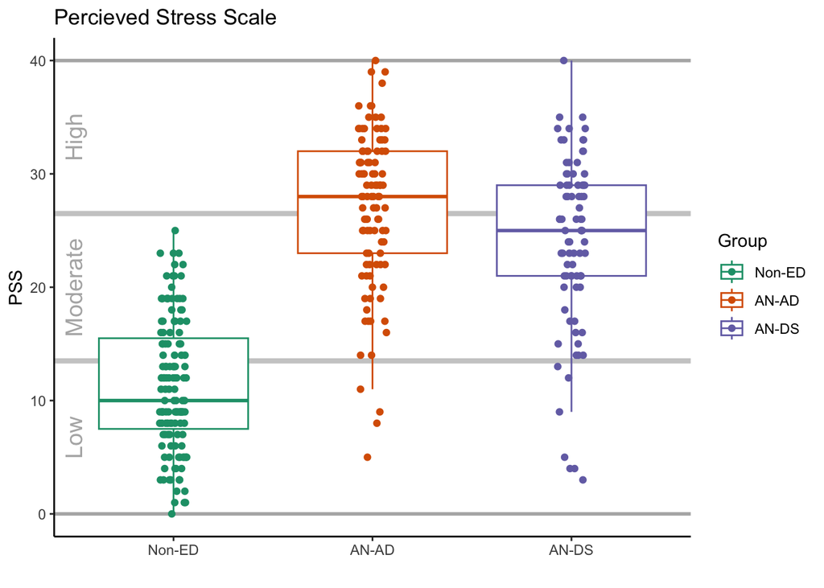

```r
p0 = ggplot(data=meta,
            aes(x=TIMEPOINT, y=PSS, col=TIMEPOINT)) +
    scale_colour_manual(values = myColorPalette,
                        labels=figureLabels, name="Group") +
    geom_hline(yintercept=pss.cat.breaks[c(2,3)], color="gray80", size=1.5) +
    geom_hline(yintercept=pss.cat.breaks[c(1,4)], color="gray70", size=1) +
    geom_boxplot(outlier.alpha = 0) +
    geom_jitter(width = .07, height = 0) +
    scale_x_discrete(labels=figureLabels, name="") +
    ggtitle("Percieved Stress Scale") +
    annotate("text", y=c(mean(pss.cat.breaks[c(1,2)]),
                         mean(pss.cat.breaks[c(2,3)]),
                         mean(pss.cat.breaks[c(3,4)])),
             x=rep(0.5,3),
             label=c("Low", "Moderate", "High"),
             color="gray70", angle=90, size=5) +
    theme_classic()
p0
```

```r
pss.plot.file = file.path(outdir, "pss-boxplot.png")
ggsave(filename = pss.plot.file, height = 7, width = 7)
```

Saved: `../output/pss-boxplot.png`